# Assignment 2: Data set Pathway and Network Analysis

Caleb Ji

2026-02-26

```r
# Necessary code to run this portion of Assignment 2 as a standalone R script
# Copied from A1 when necessary

library(GEOquery)
library(rmarkdown)
library(readr)
library(dplyr)

curr_gse <- "GSE253362"

# making sure that I do not download a new file every time I rerun this notebook
raw_counts_file = "data/GSE253362/GSE253362_rawcounts_mubritinib.tsv"
if (!file.exists(raw_counts_file)) {
  source("./fetch_geo_supp.R")
  GEOquery::fetch_geo_supp(gse = curr_gse)
  path <- file.path("data",curr_gse)
  files <- list.files(path, pattern = params$file_grep,
                      full.names = TRUE, recursive = TRUE)
  raw_counts_file <- sub("\\.gz$", "", files[1])
  # remove the .gz because the data downloaded is not compressed even though it
  # pretends to be... Not sure why, probably an error with the data upload on
  # the author's end
  file.rename(files, raw_counts_file)
}

raw_counts_data <- readr::read_tsv(raw_counts_file, show_col_types = FALSE)

library(biomaRt)
# Function from lecture that strips ensembl version numbers from the id
strip_ensembl_version <- function(x) sub("\\..*$", "", x)

# Force the underlying data as a vector, not a dataframe.
ids <- raw_counts_data[["ensembl_id"]]
ensembl_ids <- unique(strip_ensembl_version(ids))
raw_counts_data$ensembl_id_trimmed <- strip_ensembl_version(ids)

# Cache gene map so the code is not as reliant on ensembl connection
cached_map <- "cached_map.rds"
if (file.exists(cached_map)) {
  gene_map <- readRDS(cached_map)
} else {
  # Pull gene map for all ensembl ids from ensembl homo sapiens dataset
  ensembl <- biomaRt::useMart("ensembl", dataset = "hsapiens_gene_ensembl")
  gene_map <- biomaRt::getBM(
    attributes = c("ensembl_gene_id", "hgnc_symbol"),
    filters = "ensembl_gene_id",
    values = ensembl_ids,
    mart = ensembl
  )
  saveRDS(gene_map, cached_map)
}

unmapped_genes = gene_map[gene_map$hgnc_symbol == "",]

# Get the details of all these ensembl ids. Cache the results
# as to not rely always on ensembl connection
cached_map <- "cached_ensg_details.rds"
if (file.exists(cached_map)) {
  ensg_details <- readRDS(cached_map)
} else {
  ensembl <- biomaRt::useMart("ensembl", dataset = "hsapiens_gene_ensembl")
  ensg_details <- biomaRt::getBM(
    attributes = c(
      "ensembl_gene_id",
      "gene_biotype"
    ),
    filters = "ensembl_gene_id",
    values  = unmapped_genes,
    mart    = ensembl
  )
  saveRDS(ensg_details, cached_map)
}

gene_map <- gene_map[gene_map$hgnc_symbol != "",]

# Get the number of unique hgnc per ensembl
dup_ensembl <- ave(
  gene_map$hgnc_symbol,
  gene_map$ensembl_gene_id,
  FUN = function(x) length(unique(x))
)

# subset rows where an Ensembl ID maps to >1 HGNC symbol
gene_map_multi <- gene_map[dup_ensembl > 1, ]

gene_map <- gene_map[gene_map$hgnc_symbol != "LINC00856",]

# Combine the mappings with raw counts
mapped_counts_data <- raw_counts_data %>% dplyr::left_join(gene_map,
                                by = join_by("ensembl_id_trimmed" ==
                                               "ensembl_gene_id"))

# For all the genes with an hgnc, combine the rows with the same hgnc symbol
mapped_counts_data <- mapped_counts_data %>%
  dplyr::filter(!is.na(hgnc_symbol)) %>%
  dplyr::select(-ensembl_id_trimmed, -ensembl_id) %>%
  dplyr::group_by(hgnc_symbol) %>%
  dplyr::summarise(dplyr::across(where(is.numeric), sum), .groups = "drop")

library(edgeR)

# Reshift gene id column to rownames
gene_ids <- mapped_counts_data[1]
mapped_counts_data <- mapped_counts_data[-1]
rownames(mapped_counts_data) <- gene_ids$hgnc_symbol

groups <- sub("-.$", "", colnames(mapped_counts_data))

# Using DGEList to represent my data
DGE_data <- edgeR::DGEList(mapped_counts_data,
                           group = groups,
                           genes = gene_ids$hgnc_symbol)

keep <- edgeR::filterByExpr(DGE_data,
                            min.count = 10,
                            min.total.count = 350)
DGE_data <- DGE_data[keep, ]

library(tidyr)
# Using TMM norm factors from edgeR for normalization
DGE_data <- edgeR::calcNormFactors(DGE_data, method = "TMM")
# Normalize on reads using cpm, non logged
norm_cpm <- edgeR::cpm(DGE_data, log = FALSE, prior.count = 1)


disp <- edgeR::estimateDisp(DGE_data)
fit <- edgeR::glmQLFit(disp)
qlf <- edgeR::glmQLFTest(fit)


qlf_table <- edgeR::topTags(qlf, n = Inf)$table
pass_fdr_df <- qlf_table %>%
  mutate(sig = FDR < 0.05)
```

```r
library(rmarkdown)
display_table <- function(dataframe, colnames) {
  copy_dataframe <- dataframe
  colnames(copy_dataframe) <- colnames
  rownames(copy_dataframe) <- NULL
  rmarkdown::paged_table(copy_dataframe)
}
```

# 1. Introduction

The chosen study was testing the effects of mubritinib on Glioblastomas, one of the most treatment-resistant cancers (Burban et al. 2025). Mubritinib is a new drug candidate and this study elucidates its effects on the body, one of the areas of study was through an RNA-seq analysis to find gene differential expressions.

The RNA-seq data was downloaded from GEO with id `GSE253362`. They had three control conditions and three test conditions on human derived self-renewing brain tumour stem cells (BTSCs).

Initial analysis in the first step of this assignment pre-processed the data through filtering, cleaning, and mapping the data to HUGO gene identifiers. The counts were normalized and differential expression was performed using `edger`’s `glm QLF` methods.

Of the `15924` genes, `5160` were differentially expressed signficantly (under FDR); `2510` genes were upregulated and `2650` genes were downregulated

# 2. Thresholded Over-representation Analysis

Thresholded over-representation analysis (ORA) was performed using g:profiler.

G:profiler (Kolberg et al. 2023) is a web system developed by the ELIXIR Estonia research institute. Published in 2007, the original paper has 1750 citations. Its subsequent updates in 2019 and 2023 has 5663 and 1470 citations respectively. This tool is widely used in research and therefore a capable system to analyze my gene sets. Its web interface is simple and intuitive to understand, it has an associated r package to script my queries, and its results are inputtable into cytoscape. Ultimately, these all make g:profiler the method of choice for thresholded over-representation analysis (ORA).

I used g:profiler web last updated on Jun 15, 2025 and the `gprofiler2` R package version `0.2.4` (Kolberg et al. 2020).

I ran g:profiler with three main datasets:

- GO Biological pathways (BP) from BioMart; releases/2025-03-16
- Reactome from BioMart; 2025-05-23
- Wikipathways from 2025-05-10

These were chosen because of their importance to the problem; focusing on biological pathways. As well, they each provide a diversity in annotation depth or breadth. GO BP is wide with many annotations, but Wikipathways is smaller. GO BP can therefore provide an overarching vision of the gene sets that are over-represented, but Reactome and Wikipathways can provide smaller level, detailed, pathways that might be more specific to the problem at hand.

Each run was performed with these g:profiler parameters:

- Organism: Human
- Highlight driver terms in GO: True
- Significance threshold: Benjamini-Hochberg FDR
- Data sources: see above

All other parameters were kept as defaults.

## 2.1 ORA with all differentially expressed genes

```r
library(gprofiler2)
# Taking the differential expression data and separating them by up/down regulation. Saving
# the files for trial running ORA on web servers.
thresholded_genes <- (pass_fdr_df %>% filter(FDR < 0.05) %>% head(300))["genes"]
thresholded_genes_up <- (pass_fdr_df %>% filter(FDR < 0.05) %>% filter(logFC > 0) %>% head(300))["genes"]
thresholded_genes_down <- (pass_fdr_df %>% filter(FDR < 0.05) %>% filter(logFC < 0) %>% head(300))["genes"]
# Ranked list is important for GSEA
ranked_list <- pass_fdr_df[order(pass_fdr_df$logFC, decreasing=TRUE),][c("genes", "logFC")]

# Writing data for potential work outside of the script.
write_csv(thresholded_genes, file="data/thresholded_gene_list.csv",
          col_names=FALSE)
write_csv(thresholded_genes_up, file="data/thresholded_gene_list_up.csv",
          col_names=FALSE)
write_csv(thresholded_genes_down, file="data/thresholded_gene_list_down.csv",
          col_names=FALSE)
write_delim(ranked_list,
          file="data/ranked_list.txt", col_names=FALSE, delim="\t")

# Obtain the gprofiler results from query
gostres <- gprofiler2::gost(query = thresholded_genes$genes,
                organism = "hsapiens", ordered_query = FALSE,
                multi_query = FALSE, significant = TRUE, exclude_iea = TRUE,
                measure_underrepresentation = FALSE, evcodes = FALSE,
                user_threshold = 0.05, correction_method = "fdr",
                domain_scope = "annotated", custom_bg = NULL,
                numeric_ns = "", sources = c("GO:BP", "REAC", "WP"),
                as_short_link = FALSE, highlight = TRUE)
```

The first test was to run g:profiler on the top 300 differentially expressed genes. From this, there were `591` genesets that were significantly enriched from the three datasets, without any thresholding.

Subsetting to GO biological pathways (GOBP), there were `405` gene sets significantly enriched. Looking at the top 10 in **Table 1**, there is evidently a lot of very large and very broad gene sets that provide little information, like “cell cycle”. It is important to make sure that these are not biasing the result.

```r
# Set parameters for how many gene sets to display in all the tables
num_gene_sets = 10 # for display
term_size_min = 5
term_size_max = 350

# Filtering for GO results
GO_BP_res <- gostres$result %>% dplyr::filter(source == "GO:BP") %>% dplyr::arrange(p_value) %>%
  dplyr::filter(significant == TRUE) %>%
  dplyr::select(term_name, p_value, term_size, intersection_size)

# Displaying the top GO results by p-value
display_table(GO_BP_res[1:num_gene_sets,],
              c("Name", "P-value", "Term Size", "Intersection Size"))
```

| Name | P-value | Term Size | Intersection Size |
| --- | --- | --- | --- |
| cell cycle process | 1.047624e-38 | 1120 | 97 |
| cell cycle | 2.034595e-37 | 1418 | 106 |
| mitotic cell cycle process | 2.034595e-37 | 651 | 75 |
| mitotic cell cycle | 2.134868e-37 | 784 | 81 |
| DNA replication | 3.771236e-28 | 226 | 42 |
| regulation of cell cycle | 7.380644e-28 | 907 | 75 |
| regulation of cell cycle process | 1.248246e-27 | 626 | 63 |
| DNA metabolic process | 6.358332e-27 | 838 | 71 |
| cell cycle phase transition | 5.433951e-24 | 457 | 51 |
| DNA-templated DNA replication | 6.590391e-24 | 143 | 32 |

**Table 1.** Top ten gene sets in the GO biological pathways dataset sorted by p-value, calculated in over representation analysis of all differentiated genes using g:profiler. This was with no threshold to gene set term size.

```r
# Filtering GO results by term size
GO_BP_term_filter_res <- GO_BP_res %>% dplyr::filter(term_size >= term_size_min,
                                                     term_size <= term_size_max)

# Displaying the top GO results by p-value after filtering
display_table(GO_BP_term_filter_res[1:num_gene_sets,],
              c("Name", "P-value", "Term Size", "Intersection Size"))
```

| Name | P-value | Term Size | Intersection Size |
| --- | --- | --- | --- |
| DNA replication | 3.771236e-28 | 226 | 42 |
| DNA-templated DNA replication | 6.590391e-24 | 143 | 32 |
| sister chromatid segregation | 2.590887e-23 | 219 | 37 |
| mitotic sister chromatid segregation | 5.520828e-23 | 180 | 34 |
| mitotic nuclear division | 4.141395e-22 | 254 | 38 |
| nuclear chromosome segregation | 1.282734e-21 | 280 | 39 |
| negative regulation of cell cycle process | 2.251191e-20 | 251 | 36 |
| negative regulation of cell cycle | 3.182500e-20 | 327 | 40 |
| negative regulation of cell cycle phase transition | 1.138731e-18 | 213 | 32 |
| positive regulation of cell cycle process | 1.958252e-18 | 217 | 32 |

Subsetting to Reactome, there were `147` gene sets significantly enriched. In **Table 3**, we see the top 10 based on p-value. As with GOBP, we see a lot of cell cycle and mitosis related gene sets, however these are not filtered for size.

```r
# Filtering the results for Reactome
REAC_res <- gostres$result %>% dplyr::filter(source == "REAC") %>% dplyr::arrange(p_value) %>%
  dplyr::filter(significant == TRUE) %>%
  dplyr::select(term_name, p_value, term_size, intersection_size)

# Displaying the top REAC results by p-value
display_table(REAC_res[1:num_gene_sets,],
              c("Name", "P-value", "Term Size", "Intersection Size"))
```

| Name | P-value | Term Size | Intersection Size |
| --- | --- | --- | --- |
| Cell Cycle, Mitotic | 1.065469e-38 | 549 | 74 |
| Cell Cycle | 3.147295e-38 | 679 | 80 |
| Mitotic G1 phase and G1/S transition | 1.229445e-20 | 148 | 31 |
| DNA strand elongation | 1.341789e-20 | 32 | 18 |
| S Phase | 1.304514e-19 | 162 | 31 |
| Cell Cycle Checkpoints | 2.244258e-19 | 289 | 39 |
| Synthesis of DNA | 6.636374e-19 | 121 | 27 |
| Activation of ATR in response to replication stress | 1.078200e-17 | 37 | 17 |
| G1/S Transition | 6.659358e-17 | 131 | 26 |
| DNA Replication | 6.305196e-16 | 187 | 29 |

**Table 3.** Top ten gene sets in the Reactome dataset sorted by -log10(pval), calculated in over representation analysis of all differentiated genes using g:profiler. This was with no threshold to gene set term size.

```r
# Filtering REAC results by term size
REAC_term_filter_res <- REAC_res %>% dplyr::filter(term_size >= term_size_min,
                                                     term_size <= term_size_max)
# Displaying the top REAC results by p-value after term filtering
display_table(REAC_term_filter_res[1:num_gene_sets,],
              c("Name", "P-value", "Term Size", "Intersection Size"))
```

| Name | P-value | Term Size | Intersection Size |
| --- | --- | --- | --- |
| Mitotic G1 phase and G1/S transition | 1.229445e-20 | 148 | 31 |
| DNA strand elongation | 1.341789e-20 | 32 | 18 |
| S Phase | 1.304514e-19 | 162 | 31 |
| Cell Cycle Checkpoints | 2.244258e-19 | 289 | 39 |
| Synthesis of DNA | 6.636374e-19 | 121 | 27 |
| Activation of ATR in response to replication stress | 1.078200e-17 | 37 | 17 |
| G1/S Transition | 6.659358e-17 | 131 | 26 |
| DNA Replication | 6.305196e-16 | 187 | 29 |
| Unwinding of DNA | 4.680577e-14 | 12 | 10 |
| Activation of the pre-replicative complex | 5.472531e-14 | 33 | 14 |

**Table 4.** Top ten gene sets in the Reactome dataset sorted by -log10(pval), calculated in over representation analysis of all differentiated genes using g:profiler. Gene sets were thresholded to be between 5 - 350 (inclusive) genes.

Wikipathways has much smaller gene sets, so thresholding was done immediately. After thresholding to gene sets larger than 5 and smaller than 350, only `39` were significantly enriched under Wikipathways (see **Table 5**). We see the first reference towards cancer in the term “Retinoblastoma gene in cancer”, but again, a lot of cell cycle related terms.

```r
# Filtering the results for Wikipathways
WP_res <- gostres$result %>% dplyr::filter(source == "WP") %>% dplyr::arrange(p_value) %>%
  dplyr::filter(significant == TRUE) %>%
  dplyr::select(term_name, p_value, term_size, intersection_size) %>%
  dplyr::filter(term_size >= term_size_min,
                term_size <= term_size_max)

# Displaying the top Wikipathways results by p-value
display_table(WP_res[1:num_gene_sets,],
              c("Name", "P-value", "Term Size", "Intersection Size"))
```

| Name | P-value | Term Size | Intersection Size |
| --- | --- | --- | --- |
| Retinoblastoma gene in cancer | 1.099561e-24 | 89 | 30 |
| DNA replication | 1.218000e-16 | 42 | 18 |
| Cell cycle | 5.362753e-14 | 120 | 24 |
| G1 to S cell cycle control | 3.938288e-13 | 64 | 18 |
| DNA IR damage and cellular response via ATR | 2.812036e-11 | 81 | 18 |
| DNA repair pathways full network | 2.160062e-08 | 119 | 18 |
| DNA mismatch repair | 2.063075e-06 | 23 | 8 |
| Fanconi anemia | 6.163686e-06 | 47 | 10 |
| Serine metabolism | 1.961399e-05 | 8 | 5 |
| DNA damage response | 2.518454e-05 | 69 | 11 |

**Table 5.** Top ten gene sets in the Wikipathways dataset sorted by -log10(pval), calculated in over representation analysis of all differentiated genes using g:profiler. Gene sets were thresholded to be between 5 - 350 (inclusive) genes.

## 2.2 ORA with up-regulated genes

A lot of the enriched gene sets was related to cell cycle. But does this mean the cell cycle was upregulated, downregulated, or both? To test this, we subset the differentially expressed genes to only those that were upregulated from control to test samples.

The same test was run, however, thresholding was consistent to restrict their size to be from 5-350 inclusive.

Overall, `660` gene sets were enriched from up-regulated genes.

To explore this, we first look at GOBP again. There were `347` gene sets enriched after thresholding. The top 10 now have no indication of cell cycle related gene sets! Now the gene sets are more related to amino acids and apotosis!

```r
# Obtain the gprofiler results from query
gostres_up <- gprofiler2::gost(query = thresholded_genes_up$genes,
                organism = "hsapiens", ordered_query = FALSE,
                multi_query = FALSE, significant = TRUE, exclude_iea = TRUE,
                measure_underrepresentation = FALSE, evcodes = FALSE,
                user_threshold = 0.05, correction_method = "fdr",
                domain_scope = "annotated", custom_bg = NULL,
                numeric_ns = "", sources = c("GO:BP", "REAC", "WP"),
                as_short_link = FALSE, highlight = TRUE)


# Filtering for GO results. Auto filtering for term size
GO_BP_res_up <- gostres_up$result %>% dplyr::filter(source == "GO:BP") %>% dplyr::arrange(p_value) %>%
  dplyr::filter(significant == TRUE) %>%
  dplyr::select(term_name, p_value, term_size, intersection_size) %>%
  dplyr::filter(term_size >= term_size_min,
                term_size <= term_size_max)

# Displaying the top GO results by p-value
display_table(GO_BP_res_up[1:num_gene_sets,],
              c("Name", "P-value", "Term Size", "Intersection Size"))
```

| Name | P-value | Term Size | Intersection Size |
| --- | --- | --- | --- |
| regulation of apoptotic signaling pathway | 2.181505e-10 | 272 | 27 |
| negative regulation of apoptotic signaling pathway | 1.154665e-09 | 169 | 21 |
| tRNA aminoacylation for protein translation | 8.973075e-09 | 38 | 11 |
| amino acid activation | 1.690226e-08 | 41 | 11 |
| tRNA aminoacylation | 1.690226e-08 | 41 | 11 |
| amino acid metabolic process | 1.965322e-07 | 243 | 21 |
| intrinsic apoptotic signaling pathway | 7.616440e-07 | 241 | 20 |
| amino acid import across plasma membrane | 2.785634e-06 | 41 | 9 |
| regulation of intrinsic apoptotic signaling pathway | 5.677667e-06 | 132 | 14 |
| neutral amino acid transport | 6.838737e-06 | 46 | 9 |

**Table 6.** Top ten gene sets in the GO biological pathways dataset sorted by -log10(pval), calculated in over representation analysis of only up-regulated genes using g:profiler. Gene sets were thresholded to be between 5 - 350 (inclusive) genes.

Continuing on, we explore Reactome and Wikipathways in the same way. Reactome has similar results to GOBP, more related to proteins/translation and amino acids (see **Table 7**). Wikipathways provided similar ideas related to proteins (see **Table 8**).

```r
# Filtering for REAC results. Auto filtering for term size
REAC_res_up <- gostres_up$result %>% dplyr::filter(source == "REAC") %>% dplyr::arrange(p_value) %>%
  dplyr::filter(significant == TRUE) %>%
  dplyr::select(term_name, p_value, term_size, intersection_size) %>%
  dplyr::filter(term_size >= term_size_min,
                term_size <= term_size_max)

# Displaying the top REAC results by p-value
display_table(REAC_res_up[1:num_gene_sets,],
              c("Name", "P-value", "Term Size", "Intersection Size"))
```

| Name | P-value | Term Size | Intersection Size |
| --- | --- | --- | --- |
| Response of EIF2AK1 (HRI) to heme deficiency | 8.501008e-12 | 15 | 10 |
| Cytosolic tRNA aminoacylation | 5.498799e-11 | 24 | 11 |
| Translation | 2.344112e-08 | 292 | 25 |
| tRNA Aminoacylation | 2.344112e-08 | 42 | 11 |
| Unfolded Protein Response (UPR) | 1.481228e-07 | 92 | 14 |
| Amino acid transport across the plasma membrane | 4.164579e-07 | 32 | 9 |
| Response of EIF2AK4 (GCN2) to amino acid deficiency | 4.092595e-06 | 102 | 13 |
| PERK regulates gene expression | 6.883087e-06 | 32 | 8 |
| Cellular response to starvation | 1.518718e-05 | 157 | 15 |
| Eukaryotic Translation Initiation | 1.337502e-04 | 120 | 12 |

**Table 7.** Top ten gene sets in the Reactome dataset sorted by -log10(pval), calculated in over representation analysis of only up-regulated genes using g:profiler. Gene sets were thresholded to be between 5 - 350 (inclusive) genes.

```r
# Filtering for Wikipathways results. Auto filtering for term size
WP_res_up <- gostres_up$result %>% dplyr::filter(source == "WP") %>% dplyr::arrange(p_value) %>%
  dplyr::filter(significant == TRUE) %>%
  dplyr::select(term_name, p_value, term_size, intersection_size) %>%
  dplyr::filter(term_size >= term_size_min,
                term_size <= term_size_max)

# Displaying the top Wikipathways results by p-value
display_table(WP_res_up[1:num_gene_sets,],
              c("Name", "P-value", "Term Size", "Intersection Size"))
```

| Name | P-value | Term Size | Intersection Size |
| --- | --- | --- | --- |
| Photodynamic therapy induced unfolded protein response | 7.876807e-11 | 27 | 12 |
| mRNA protein and metabolite inducation pathway by cyclosporin A | 1.865134e-05 | 7 | 5 |
| Unfolded protein response | 5.977713e-05 | 23 | 7 |
| Ferroptosis | 1.406816e-04 | 64 | 10 |
| Apoptosis related network due to altered Notch3 in ovarian cancer | 1.949336e-04 | 53 | 9 |
| Amino acid metabolism in triple negative breast cancer cells | 5.939906e-04 | 7 | 4 |
| Transcriptional activation by NRF2 in response to phytochemicals | 7.547956e-04 | 15 | 5 |
| Neuroinflammation and glutamatergic signaling | 7.547956e-04 | 140 | 13 |
| Translation factors | 7.547956e-04 | 50 | 8 |
| NRF2 ARE regulation | 6.073770e-03 | 23 | 5 |

**Table 8.** Top ten gene sets in the Wikipathways dataset sorted by -log10(pval), calculated in over representation analysis of only up-regulated genes using g:profiler. Gene sets were thresholded to be between 5 - 350 (inclusive) genes.

## 2.3 ORA with down-regulated genes

If the cell cycle enrichment did not appear in the up-regulated gene enrichment, it should appear in the down-regulated gene enrichment.

```r
# Obtain the gprofiler results from query
gostres_down <- gprofiler2::gost(query = thresholded_genes_down$genes,
                organism = "hsapiens", ordered_query = FALSE,
                multi_query = FALSE, significant = TRUE, exclude_iea = TRUE,
                measure_underrepresentation = FALSE, evcodes = FALSE,
                user_threshold = 0.05, correction_method = "fdr",
                domain_scope = "annotated", custom_bg = NULL,
                numeric_ns = "", sources = c("GO:BP", "REAC", "WP"),
                as_short_link = FALSE, highlight = TRUE)


# Filtering for GO results. Auto filtering for term size
GO_BP_res_down <- gostres_down$result %>% dplyr::filter(source == "GO:BP") %>% dplyr::arrange(p_value) %>%
  dplyr::filter(significant == TRUE) %>%
  dplyr::select(term_name, p_value, term_size, intersection_size) %>%
  dplyr::filter(term_size >= term_size_min,
                term_size <= term_size_max)

# Displaying the top GO results by p-value
display_table(GO_BP_res_down[1:num_gene_sets,],
              c("Name", "P-value", "Term Size", "Intersection Size"))
```

| Name | P-value | Term Size | Intersection Size |
| --- | --- | --- | --- |
| DNA replication | 4.955923e-53 | 226 | 61 |
| DNA-templated DNA replication | 7.479999e-45 | 143 | 47 |
| sister chromatid segregation | 1.160430e-40 | 219 | 51 |
| mitotic sister chromatid segregation | 7.168424e-40 | 180 | 47 |
| nuclear chromosome segregation | 7.735860e-40 | 280 | 55 |
| mitotic nuclear division | 1.543157e-38 | 254 | 52 |
| positive regulation of cell cycle process | 2.115258e-38 | 217 | 49 |
| regulation of mitotic cell cycle phase transition | 3.413224e-35 | 279 | 51 |
| positive regulation of cell cycle | 1.104583e-34 | 271 | 50 |
| negative regulation of cell cycle process | 5.382157e-34 | 251 | 48 |

**Table 9.** Top ten gene sets in the GO biological pathways dataset sorted by -log10(pval), calculated in over representation analysis of only down-regulated genes using g:profiler. Gene sets were thresholded to be between 5 - 350 (inclusive) genes.

```r
# Filtering for Reactome results. Auto filtering for term size
REAC_res_down <- gostres_down$result %>% dplyr::filter(source == "REAC") %>% dplyr::arrange(p_value) %>%
  dplyr::filter(significant == TRUE) %>%
  dplyr::select(term_name, p_value, term_size, intersection_size) %>%
  dplyr::filter(term_size >= term_size_min,
                term_size <= term_size_max)

# Displaying the top Reactome results by p-value
display_table(REAC_res_down[1:num_gene_sets,],
              c("Name", "P-value", "Term Size", "Intersection Size"))
```

| Name | P-value | Term Size | Intersection Size |
| --- | --- | --- | --- |
| Cell Cycle Checkpoints | 2.786987e-40 | 289 | 57 |
| Mitotic G1 phase and G1/S transition | 4.303621e-36 | 148 | 42 |
| DNA strand elongation | 8.379122e-36 | 32 | 25 |
| S Phase | 8.379122e-36 | 162 | 43 |
| Synthesis of DNA | 4.028380e-33 | 121 | 37 |
| G1/S Transition | 9.621458e-32 | 131 | 37 |
| DNA Replication | 2.682511e-29 | 187 | 40 |
| Activation of ATR in response to replication stress | 2.689420e-29 | 37 | 23 |
| Activation of the pre-replicative complex | 4.568497e-25 | 33 | 20 |
| G2/M Checkpoints | 5.042094e-24 | 167 | 34 |

**Table 10.** Top ten gene sets in the Reactome dataset sorted by -log10(pval), calculated in over representation analysis of only down-regulated genes using g:profiler. Gene sets were thresholded to be between 5 - 350 (inclusive) genes.

```r
# Filtering for Wikipathways results. Auto filtering for term size
WP_res_down <- gostres_down$result %>% dplyr::filter(source == "WP") %>% dplyr::arrange(p_value) %>%
  dplyr::filter(significant == TRUE) %>%
  dplyr::select(term_name, p_value, term_size, intersection_size) %>%
  dplyr::filter(term_size >= term_size_min,
                term_size <= term_size_max)

# Displaying the top Wikipathways results by p-value
display_table(WP_res_down[1:num_gene_sets,],
              c("Name", "P-value", "Term Size", "Intersection Size"))
```

| Name | P-value | Term Size | Intersection Size |
| --- | --- | --- | --- |
| Retinoblastoma gene in cancer | 6.309452e-54 | 89 | 47 |
| DNA replication | 1.462394e-31 | 42 | 26 |
| Cell cycle | 4.172187e-26 | 120 | 33 |
| G1 to S cell cycle control | 6.200863e-24 | 64 | 25 |
| DNA repair pathways full network | 6.824472e-19 | 119 | 27 |
| DNA mismatch repair | 1.015036e-16 | 23 | 14 |
| DNA IR damage and cellular response via ATR | 6.251920e-16 | 81 | 21 |
| DNA damage response | 6.073343e-09 | 69 | 14 |
| miRNA regulation of DNA damage response | 1.197631e-08 | 73 | 14 |
| Nucleotide excision repair | 3.413589e-08 | 43 | 11 |

**Table 11.** Top ten gene sets in the Wikipathways dataset sorted by -log10(pval), calculated in over representation analysis of only down-regulated genes using g:profiler. Gene sets were thresholded to be between 5 - 350 (inclusive) genes.

## 2.4 Interpretation

Overall, we see a clear divide between the up-regulated gene set, down-regulated gene set, and the combination of the both. The combination has a lot of signal into cell-cycle related gene sets, with some variety. However, that variety disappears in the down-regulated analysis where almost all of the top enriched genes are cell cycle related. Whereas cell cycle related gene sets disappears in the up-regulated analysis. Ultimately, this shows the clear biological signal of the difference between what is up-regulated and down-regulated.

The original paper (Burban et al. 2025) discussed two main pathways: it impairs the AMPK/p27 pathway and deregulates the cell cycle. I can clearly validate the idea of deregulation of the cell cycle, as there is an overwhelming signal that it is down-regulated through the enrichment with the down-regulated gene set analysis.

The down-regulation of the AMPK/p27 pathway is a little harder to verify. The paper claims that these pathways are down-regulated: including cyclin D1-associated events in G1, SCF SKP2-mediated degradation of p27/p21 and E2F-mediated regulation of DNA replication. None of these appeared clearly in the top hits of the thresholded analysis.

After some searching: I found `E2F-mediated regulation of DNA replication` was a reactome pathway downregulated with a p-value of 5.58e-08 and `SCF SKP2-mediated degradation of p27/p21` was a reactome pathway downregulated with a p-value of 0.024.

Though these were clear signs that something is biologically happening here, it was not convincing enough proof to say the paper was right, and mubritinib affects the AMPK/p27 pathway.

```r
# exploring the datasets for pathways that match the paper.
GO_related_e2f <- grep("E2F", GO_BP_res_down$term_name) # empty
reac_related_e2f <- grep("E2F", REAC_res_down$term_name)
GO_related_p27 <- grep("p27", GO_BP_res_down$term_name) # empty
reac_related_p27 <-grep("p27", REAC_res_down$term_name)
reac_related_D1 <-grep("D1", REAC_res_down$term_name) # empty


res_e2f <- REAC_res_down[reac_related_e2f, ]
res_p27 <- REAC_res_down[reac_related_p27, ]
```

# 3. Non-thresholded Gene Set Enrichment Analysis (GSEA)

Thresholded gene set analysis provided a lot of insight, but signal could have been lost through the removal of gene that are not significantly differentially expressed. Some drug effects may not be seen in large changes but many small changes.

I perform non-thresholded GSEA with `fgsea` (Korotkevich et al. 2019), a fast GSEA alternative that is run entirely in R. I chose this because it closely models after the original GSEA(Subramanian et al. 2005), providing the data necessary to create plots on the leading edge. The original GSEA is an industry standard, cited `57039` times. However, `fgsea` is much faster and much easier to use as it is not in a separate java application.

`fgsea` R package was run on version `1.34.2`.

This run was conducted on the Bader’s lab’s curated gene sets `.gmt` file, specifically with these parameters:

- Organism: Human
- GO Biological Pathways
- All pathways
- No PFOCR
- No GO IEA
- September 1, 2025

## 3.1 Exploration of Individual Gene Set Enrichment

#### Top Pathway Enrichment Scores

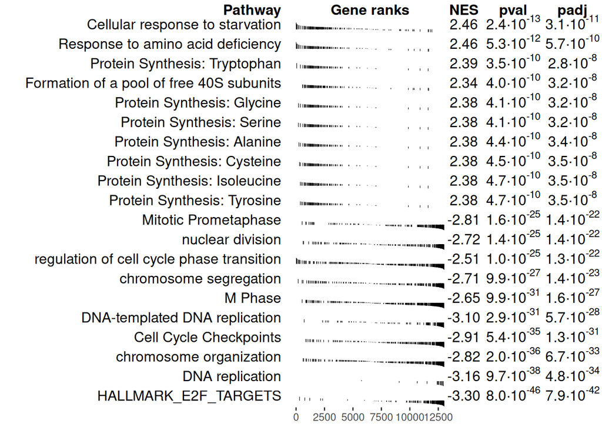

```r
# Add desscription column to gsea results so that resulting plots can use the description instead
# of the pathway name
name_mapping = data.frame(pathway=gmt_data$geneset.names, description=gmt_data$geneset.descriptions)
pathways_data_renamed <- pathways_data
names(pathways_data_renamed) <- gmt_data$geneset.descriptions
gsea_res_reordered <- gsea_res %>% dplyr::left_join(name_mapping, by="pathway") %>%
  dplyr::rename(pathway_old = pathway, pathway = description) %>%
  dplyr::relocate("pathway", .before="pathway_old") %>%
  dplyr::relocate("pathway_old", .after="leadingEdge")

# Rename some names that are too long for display
old_name <- "Response of EIF2AK4 (GCN2) to amino acid deficiency"
new_name <- "Response to amino acid deficiency"
names(pathways_data_renamed)[names(pathways_data_renamed) == old_name] <- new_name
gsea_res_reordered$pathway[gsea_res_reordered$pathway == old_name] <- new_name

topPathwaysUp <- gsea_res_reordered[ES > 0][head(order(pval), n=10), pathway]
topPathwaysDown <- gsea_res_reordered[ES < 0][head(order(pval), n=10), pathway]
topPathways <- c(topPathwaysUp, rev(topPathwaysDown))
fgsea::plotGseaTable(pathways_data_renamed[topPathways],
                     fgsea_format_ranks,
                     gsea_res_reordered,
                     gseaParam=0.5,
                     headerLabelStyle = list(size=12, fontface="bold"),
                     colwidths = c(6, 3, 0.8, 1.2, 1.2))
```

**Figure 1.** The top ten enriched pathways for each up-regulated and down-regulated categories are shown. Top ten is determined by lowest p-value. Their pathway names, normalized enrichment score (NES), pvalues, and adjusted pvalues (FDR correction) are shown. Gene ranks shows a condensed enrichment plot that shows what genes contributed to the pathway enrichment.

The top ten up-regulated and down-regulated gene sets hold very clear patterns. Seven of the top ten gene sets that were upregulated were related to protein synthesis. Obviously, these are all gene sets that are closely related, and one being enriched causes many of the others to be enriched as well. However, we also see amino acid deficiency and starvation pathways, a related, but different idea.

The down-regulated genes continue to have a lot to do with the cell cycle. Mitosis, cell cycle checkpoints, and DNA replication are all among the top ten. The most enriched set with a negative NES related to E2F targets, however, E2F is a clear actor in cell cycle, integrating cell cycle progression with DNA repair (Ren et al. 2002).

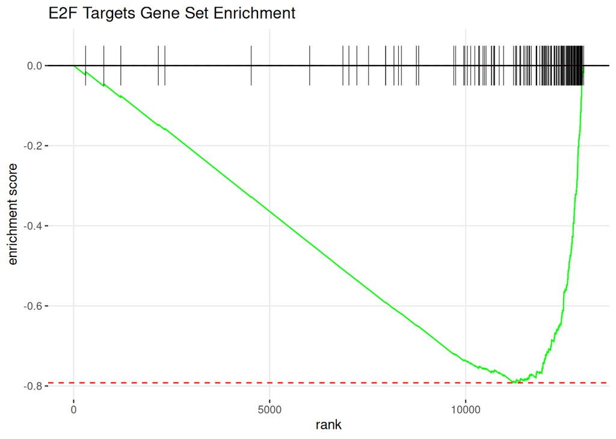

```r
fgsea::plotEnrichment(pathways_data[["HALLMARK_E2F_TARGETS%MSIGDBHALLMARK%HALLMARK_E2F_TARGETS"]],
               fgsea_format_ranks) + ggplot2::labs(title="E2F Targets Gene Set Enrichment")
```

**Figure 2.** The GSEA enrichment plot for HALLMARK E2F Targets. The green line represents the cumulative enrichment score, peaking at the dotted red line, which is the minimum enrichment score reached by the leading edge. Each black line on the x-axis represents a gene in the gene set and the rank which it is differentially expressed. Since this is down-regulated, the enrichment scores are negative.

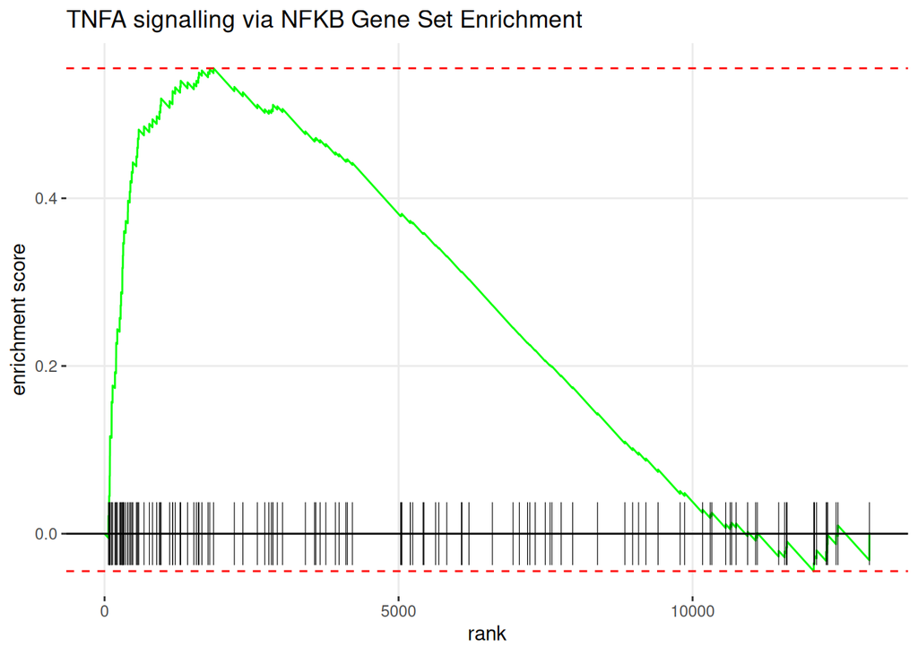

```r
fgsea::plotEnrichment(pathways_data[["HALLMARK_TNFA_SIGNALING_VIA_NFKB%MSIGDBHALLMARK%HALLMARK_TNFA_SIGNALING_VIA_NFKB"]],
               fgsea_format_ranks) + ggplot2::labs(title="TNFA signalling via NFKB Gene Set Enrichment")
```

**Figure 3.** The GSEA enrichment plot for HALLMARK TNFA Signaling via NFKB. The green line represents the cumulative enrichment score, peaking at the dotted red line, which is the maximum enrichment score reached by the leading edge. Each black line on the x-axis represents a gene in the gene set and the rank which it is differentially expressed.

Therefore, in terms of the down-regulated pathways and gene sets, these two analyses come to very similar conclusions. Cell cycle is being down-regulated. Mitosis, cell checkpoints, DNA replication, etc. In both analyses, 10/10 of the top enriched pathways related to the cell cycle (in ORA, we are looking at Reactome pathways).

The simplicity slightly deviates when looking at up-regulation. There is less clear of a signal on what is being up-regulated, and it shows. This is where the differences in the analysis can shine. Since ORA only had 300 genes to work with, not as much depth of information could be processed. As we see in the gene ranks of the up-regulated pathways (**Figure 1**), the genes in the leading edge are not as clustered to the front. These genes are what ORA would not pick up on. As a result, we see a whole class of protein synthesis pathways being enriched for in fGSEA, that ORA did not pick up on.

Despite this, we still see similar themes, of proteins synthesis, amino acids, and related pathways.

I think this analysis is unique because of the clear biological signal. ORA loses information relative to GSEA, but the signal is still strong enough to provide clear results. Ultimately, a less biologically clear RNA-seq dataset might find more differences between the two.

## 3.2 Exploration of Gene Set Enrichments Using Cytoscape

Cytoscape is used to further explore the gene set enrichments, to see if larger scale patterns can be elucidated from the visualizations.

The fgsea data was imported into the Cytoscape app [Shannon2003-su]. There were 666 nodes and 5350 edges, with a node cutoff of 0.005 Q-value and a 0.375 edge similarity cutoff. **Figure 3** shows the network before annotation and manual layout.

#### Raw Enrichment Map Representation

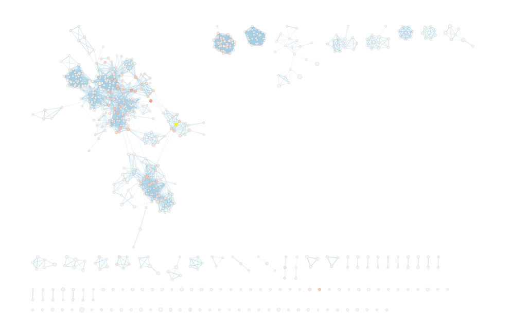

**Figure 3.** Raw enrichment map network created from Cytoscape, nodes are pathways and each edge represents a significant amount of genes that are shared between the gene sets. They are clustered and organized by cluster size.

The network was then annotated using AutoAnnotate (Kucera et al. 2016), with quick start parameters of a central amount of clusters, labels from the pathways descriptions, and no layout to minimize cluster overlap. Nodes were colored based on -log(pval) * sign(NES). Since the p-values were so skewed towards negative NES, more color weight was given to values below zero so the differences could be easily spotted. **Figure 4** shows this annotated network, and as expected most of the networks are blue (down-regulated) and related to each other, presumably to do with the cell cycle.

#### Curated and Annotated Enrichment Map Representation

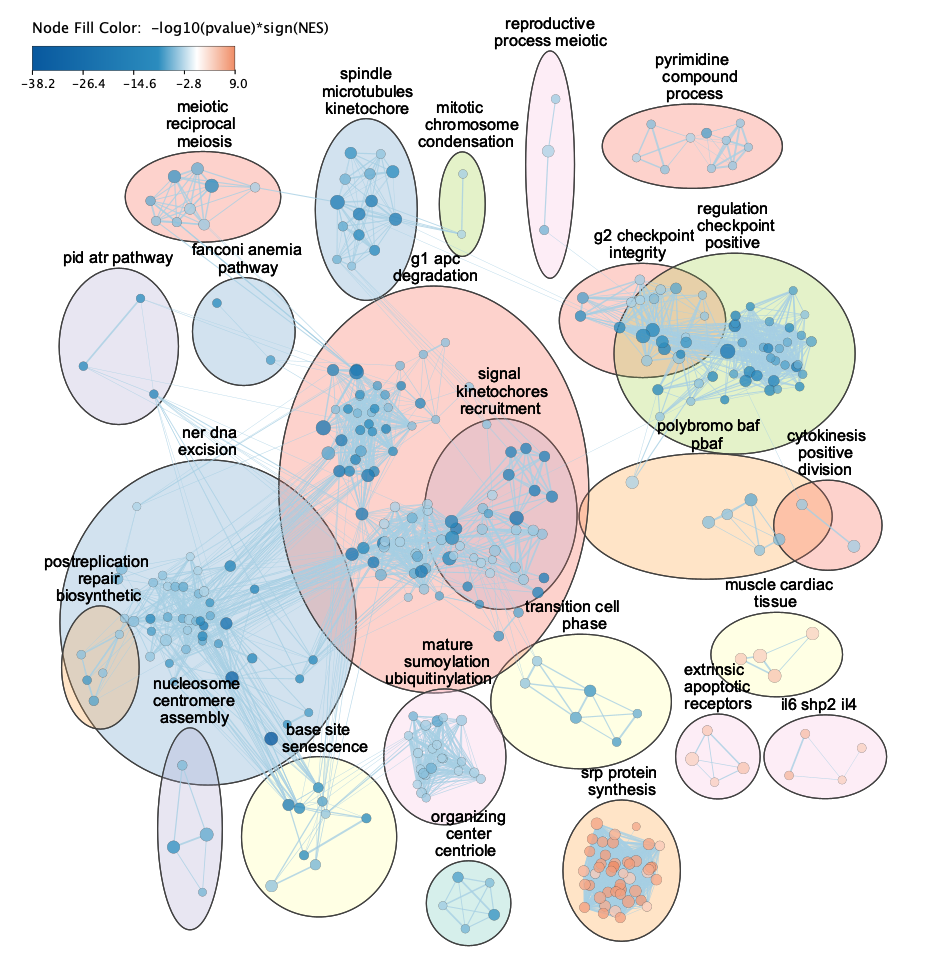

**Figure 4.** Annotated and curated enrichment map network from Cytoscape. Each cluster is labeled and encapsulated with an ellipse. Node colors are based on -log(pval) * sign(NES), which means blue nodes are significantly down-regulated pathways and red nodes are significantly up-regulated pathways.

To explore how these clusters relate to each other, a condensed theme network was created (**Figure 5**). The main focus is on the nodes that are connected. As evident in the figure, a lot of down-regulated gene set clusters ar econnected in one big network, and these all have to do with the cell cycle! This confirms that the trends we saw in the top pathways propogate throughout all enriched pathways. Interestingly, three up-regulated gene set clusters were connected: hormone stimulus, interleukin-6/4 pathway, and focal adhesion. These are related to growth / metabolism / extracellular matrix respectively.

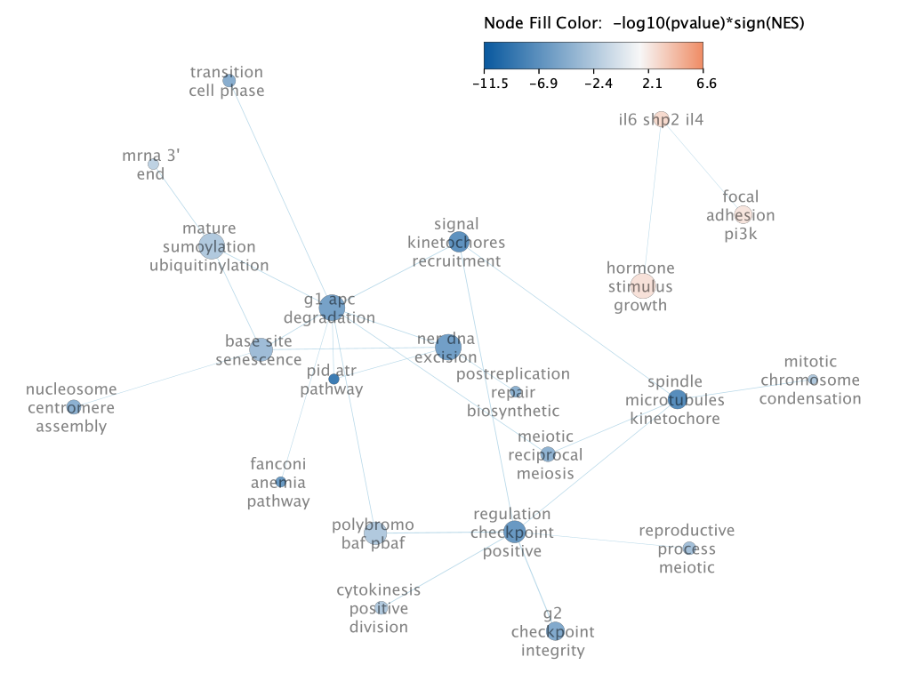

**Figure 5.** Theme network analysis, the clusters from AutoAnnotate are condensed into nodes, and connections are representing connections between gene sets in the cluster. Node color is still representing -log(pval) * sign(NES), just aggregated on a cluster scale.

# 4. Interpretation of results

There are three main interesting points:

1. ORA and GSEA have deceptively similar results
2. Cell cycle elements are clearly (really strikingly clear) being down-regulated by mubritinib
3. Up-regulated elements are less clearly connected.

First, ORA and GSEA have similar results. This is mainly driven by the fact that there is such a clear action that mubritinib has against the cell cycle, that even thresholded analyses can’t avoid the obvious.

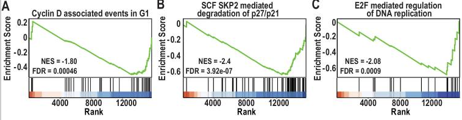

**Figure 6** The GSEA results from (Burban et al. 2025), with the three main pathways that connect to the AMPK/p27 pathway that the authors discovered being down-regulated. This was their main evidence to suggest mubritinib’s involvement in this pathway.

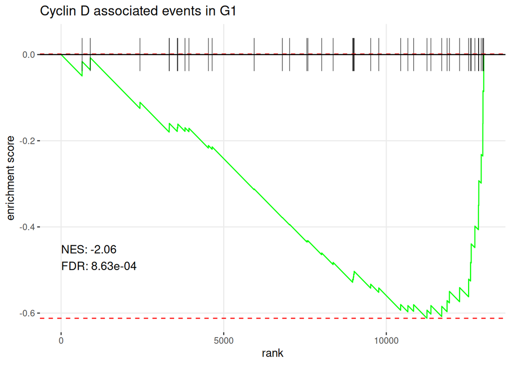

```r
plot_fgsea("CYCLIN D ASSOCIATED EVENTS IN G1%REACTOME%R-HSA-69231.11",
           "Cyclin D associated events in G1",
           pathways_data,
           fgsea_format_ranks,
           gsea_res,
           y_val=-0.5)
```

**Figure 7** The GSEA enrichment plot for Cyclin D associated events in G1. The green line represents the cumulative enrichment score, peaking at the dotted red line, which is the minimum enrichment score reached by the leading edge. Each black line on the x-axis represents a gene in the gene set and the rank which it is differentially expressed. Since this is down-regulated, the enrichment scores are negative.

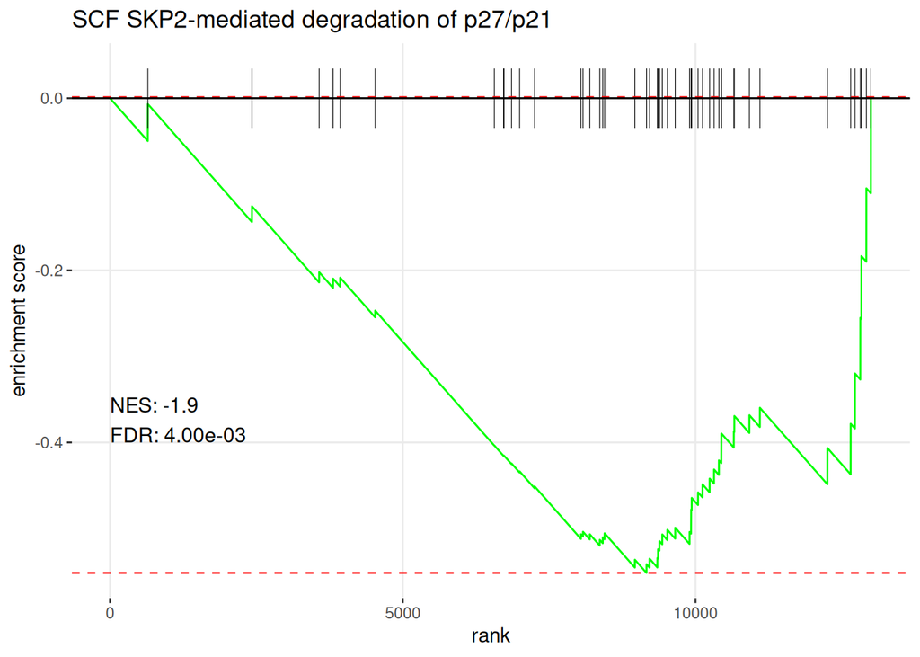

```r
plot_fgsea("SCF(SKP2)-MEDIATED DEGRADATION OF P27 P21%REACTOME%R-HSA-187577.5",
           "SCF SKP2-mediated degradation of p27/p21",
           pathways_data,
           fgsea_format_ranks,
           gsea_res,
           y_val=-0.4)
```

**Figure 8** The GSEA enrichment plot for SCF SKP2-mediated degradation of p27/p21. The green line represents the cumulative enrichment score, peaking at the dotted red line, which is the minimum enrichment score reached by the leading edge. Each black line on the x-axis represents a gene in the gene set and the rank which it is differentially expressed. Since this is down-regulated, the enrichment scores are negative.

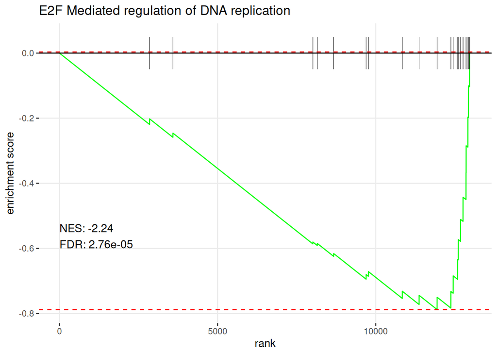

```r
plot_fgsea("E2F MEDIATED REGULATION OF DNA REPLICATION%REACTOME DATABASE ID RELEASE 93%113510",
           "E2F Mediated regulation of DNA replication",
           pathways_data,
           fgsea_format_ranks,
           gsea_res,
           y_val=-0.6)
```

**Figure 9** The GSEA enrichment plot for E2F Mediated regulation of DNA replication. The green line represents the cumulative enrichment score, peaking at the dotted red line, which is the minimum enrichment score reached by the leading edge. Each black line on the x-axis represents a gene in the gene set and the rank which it is differentially expressed. Since this is down-regulated, the enrichment scores are negative.

Second of all, the cell cycle is clearly being disrupted here. It is clear in the literature (Shapiro and Harper 1999) that effective anti-cancer drugs target the cell cycle. Tumors are characterized by their increased rate of replication, reducing this disrupts the cancer’s effectiveness and growth. Mubritinib is another example of this, a drug that inhibits the AMPK/p27 pathway, down-regulating the cell cycle, and controlling aggressive cancers.

However, third of all is understanding what is going on with the up-regulation. The main insight is that these are not actual mechanisms of mubritinib, but rather side effects of its main function which is downregulating the cell cycle. Since a cell is no longer working to divide, it instead focuses on metabolic activity and providing proteins necessary for growth. Papers show that AMPK regulates metabolic programs (Hardie et al. 2012). As well, translation pathways may be increased because of disruption to the cell state (drug treatment), and is a response to the increase in stress (Mahé et al. 2024).

# 5. Questions

## 5.1 Thresholded Over-Representation Analysis

#### Which method did you choose and why?

Thresholded over-representation analysis (ORA) was performed using g:profiler.

G:profiler is a web system developed by the ELIXIR Estonia research institute. Published in 2007, the original paper has 1750 citations. Its subsequent updates in 2019 and 2023 has 5663 and 1470 citations respectively. This tool is widely used in research and therefore a capable system to analyze my gene sets. Its web interface is simple and intuitive to understand, it has an associated r package to script my queries, and its results are inputtable into cytoscape. Ultimately, these all make g:profiler the method of choice for thresholded over-representation analysis (ORA).

#### What annotation data did you use and why? What version of the annotation are you using?

I ran g:profiler with three main datasets:

- GO Biological pathways (BP) from BioMart; releases/2025-03-16
- Reactome from BioMart; 2025-05-23
- Wikipathways from 2025-05-10

These were chosen because of their importance to the problem; focusing on biological pathways. As well, they each provide a diversity in annotation depth or breadth. GO BP is wide with many annotations, but Wikipathways is smaller. GO BP can therefore provide an overarching vision of the gene sets that are over-represented, but Reactome and Wikipathways can provide smaller level, detailed, pathways that might be more specific to the problem at hand.

#### How many genesets were returned with what thresholds?

Subsetting to GO biological pathways (GOBP), there were `405` gene sets significantly enriched.

Subsetting to Reactome, there were `147` gene sets significantly enriched.

After thresholding to gene sets larger than 5 and smaller than 350, only `136` were significantly enriched under Reactome.

After thresholding to gene sets larger than 5 and smaller than 350, only `39` were significantly enriched under Wikipathways

#### Run the analysis using the up-regulated set of genes, and the down-regulated set of genes separately. How do these results compare to using the whole list (i.e all differentially expressed genes together vs. the up-regulated and down regulated differentially expressed genes separately)?

Overall, we see a clear divide between the up-regulated gene set, down-regulated gene set, and the combination of the both. The combination has a lot of signal into cell-cycle related gene sets, with some variety. However, that variety disappears in the down-regulated analysis where almost all of the top enriched genes are cell cycle related. Whereas cell cycle related gene sets disappears in the up-regulated analysis. Ultimately, this shows the clear biological signal of the difference between what is up-regulated and down-regulated.

#### Do the over-representation results support conclusions or mechanism discussed in the original paper?

The original paper (Burban et al. 2025) discussed two main pathways: it impairs the AMPK/p27 pathway and deregulates the cell cycle. I can clearly validate the idea of deregulation of the cell cycle, as there is an overwhelming signal that it is down-regulated through the enrichment with the down-regulated gene set analysis.

The down-regulation of the AMPK/p27 pathway is a little harder to verify. The paper claims that these pathways are down-regulated: including cyclin D1-associated events in G1, SCF SKP2-mediated degradation of p27/p21 and E2F-mediated regulation of DNA replication. None of these appeared clearly in the top hits of the thresholded analysis.

After some searching: I found `E2F-mediated regulation of DNA replication` was a reactome pathway downregulated with a p-value of 5.58e-08 and `SCF SKP2-mediated degradation of p27/p21` was a reactome pathway downregulated with a p-value of 0.024.

Though these were clear signs that something is biologically happening here, it was not convincing enough proof to say the paper was right, and mubritinib affects the AMPK/p27 pathway.

#### Can you find evidence, i.e. publications, to support some of the results that you see. How does this evidence support your results.

Second of all, the cell cycle is clearly being disrupted here. It is clear in the literature (Shapiro and Harper 1999) that effective anti-cancer drugs target the cell cycle. Tumors are characterized by their increased rate of replication, reducing this disrupts the cancer’s effectiveness and growth. Mubritinib is another example of this, a drug that inhibits the AMPK/p27 pathway, down-regulating the cell cycle, and controlling aggressive cancers.

However, third of all is understanding what is going on with the up-regulation. The main insight is that these are not actual mechanisms of mubritinib, but rather side effects of its main function which is downregulating the cell cycle. Since a cell is no longer working to divide, it instead focuses on metabolic activity and providing proteins necessary for growth. Papers show that AMPK regulates metabolic programs (Hardie et al. 2012). As well, translation pathways may be increased because of disruption to the cell state (drug treatment), and is a response to the increase in stress (Mahé et al. 2024).

## 5.2 Non-thresholded Gene Set Enrichment Analysis

#### What method did you use? What genesets did you use? Make sure to specify versions and cite your methods.

I perform non-thresholded GSEA with `fgsea`, a fast GSEA alternative that is run entirely in R. I chose this because it closely models after the original GSEA, providing the data necessary to create plots on the leading edge. The original GSEA is an industry standard, cited `57039` times. However, `fgsea` is much faster and much easier to use as it is not in a separate java application.

`fgsea` R package was run on version `1.34.2`.

#### Summarize your enrichment results.

The top ten up-regulated and down-regulated gene sets hold very clear patterns. Seven of the top ten gene sets that were upregulated were related to protein synthesis. Obviously, these are all gene sets that are closely related, and one being enriched causes many of the others to be enriched as well. However, we also see amino acid deficiency and starvation pathways, a related, but different idea.

The down-regulated genes continue to have a lot to do with the cell cycle. Mitosis, cell cycle checkpoints, and DNA replication are all among the top ten. The most enriched set with a negative NES related to E2F targets, however, E2F is a clear actor in cell cycle, integrating cell cycle progression with DNA repair (Ren et al. 2002).

#### How do these results compare to the results from the thresholded analysis in Assignment #2. Compare qualitatively. Is this a straight forward comparison? Why or why not?

Therefore, in terms of the down-regulated pathways and gene sets, these two analyses come to very similar conclusions. Cell cycle is being down-regulated. Mitosis, cell checkpoints, DNA replication, etc. In both analyses, 10/10 of the top enriched pathways related to the cell cycle (in ORA, we are looking at Reactome pathways).

The simplicity slightly deviates when looking at up-regulation. There is less clear of a signal on what is being up-regulated, and it shows. This is where the differences in the analysis can shine. Since ORA only had 300 genes to work with, not as much depth of information could be processed. As we see in the gene ranks of the up-regulated pathways (**Figure 1**), the genes in the leading edge are not as clustered to the front. These genes are what ORA would not pick up on. As a result, we see a whole class of protein synthesis pathways being enriched for in fGSEA, that ORA did not pick up on.

Despite this, we still see similar themes, of proteins synthesis, amino acids, and related pathways.

I think this analysis is unique because of the clear biological signal. ORA loses information relative to GSEA, but the signal is still strong enough to provide clear results. Ultimately, a less biologically clear RNA-seq dataset might find more differences between the two.

## 5.3 Visualize Gene Set Enrichment Analysis in Cytoscape

#### Create an enrichment map - how many nodes and how many edges in the resulting map? What thresholds were used to create this map? Make sure to record all thresholds. Include a screenshot of your network prior to manual layout.

The network was then annotated using AutoAnnotate (Kucera et al. 2016), with quick start parameters of a central amount of clusters, labels from the pathways descriptions, and no layout to minimize cluster overlap.

#### Collapse your network to a theme network. What are the major themes present in this analysis? Do they fit with the model? Are there any novel pathways or themes?

As evident in the figure, a lot of down-regulated gene set clusters ar econnected in one big network, and these all have to do with the cell cycle! This confirms that the trends we saw in the top pathways propogate throughout all enriched pathways. Interestingly, three up-regulated gene set clusters were connected: hormone stimulus, interleukin-6/4 pathway, and focal adhesion. These are related to growth / metabolism / extracellular matrix respectively.

#### Can you find evidence, i.e. publications, to support some of the results that you see. How does this evidence support your result?

Second of all, the cell cycle is clearly being disrupted here. It is clear in the literature (Shapiro and Harper 1999) that effective anti-cancer drugs target the cell cycle. Tumors are characterized by their increased rate of replication, reducing this disrupts the cancer’s effectiveness and growth. Mubritinib is another example of this, a drug that inhibits the AMPK/p27 pathway, down-regulating the cell cycle, and controlling aggressive cancers.

However, third of all is understanding what is going on with the up-regulation. The main insight is that these are not actual mechanisms of mubritinib, but rather side effects of its main function which is downregulating the cell cycle. Since a cell is no longer working to divide, it instead focuses on metabolic activity and providing proteins necessary for growth. Papers show that AMPK regulates metabolic programs (Hardie et al. 2012). As well, translation pathways may be increased because of disruption to the cell state (drug treatment), and is a response to the increase in stress (Mahé et al. 2024).

# 6. Referencs

Allaire, JJ, Yihui Xie, Christophe Dervieux, et al. 2025. *Rmarkdown: Dynamic Documents for r*. https://github.com/rstudio/rmarkdown.

Burban, Audrey, Cloe Tessier, Mathieu Larroquette, et al. 2025. “Exploiting Metabolic Vulnerability in Glioblastoma Using a Brain-Penetrant Drug with a Safe Profile.” *EMBO Mol. Med.* 17 (3): 469–503.

Chen, Yunshun, Lizhong Chen, Aaron T L Lun, Pedro Baldoni, and Gordon K Smyth. 2025. “edgeR V4: Powerful Differential Analysis of Sequencing Data with Expanded Functionality and Improved Support for Small Counts and Larger Datasets.” *Nucleic Acids Research* 53 (2): gkaf018. https://doi.org/10.1093/nar/gkaf018.

Davis, Sean, and Paul Meltzer. 2007. “GEOquery: A Bridge Between the Gene Expression Omnibus (GEO) and BioConductor.” *Bioinformatics* 14: 1846–47. https://doi.org/10.1093/bioinformatics/btm254.

Durinck, Steffen, Yves Moreau, Arek Kasprzyk, et al. 2005. “BioMart and Bioconductor: A Powerful Link Between Biological Databases and Microarray Data Analysis.” *Bioinformatics* 21: 3439–40.

Efron, Brad, and R. Tibshirani. 2024. *GSA: Gene Set Analysis*. https://tibshirani.su.domains/GSA/.

Hardie, D Grahame, Fiona A Ross, and Simon A Hawley. 2012. “AMPK: A Nutrient and Energy Sensor That Maintains Energy Homeostasis.” *Nat. Rev. Mol. Cell Biol.* 13 (4): 251–62.

Kolberg, Liis, Uku Raudvere, Ivan Kuzmin, Priit Adler, Jaak Vilo, and Hedi Peterson. 2023. “G:profiler-Interoperable Web Service for Functional Enrichment Analysis and Gene Identifier Mapping (2023 Update).” *Nucleic Acids Res.* 51 (W1): W207–12.

Kolberg, Liis, Uku Raudvere, Ivan Kuzmin, Jaak Vilo, and Hedi Peterson. 2020. “Gprofiler2– an r Package for Gene List Functional Enrichment Analysis and Namespace Conversion Toolset g:profiler.” *F1000Research* 9 (ELIXIR) (709).

Korotkevich, Gennady, Vladimir Sukhov, and Alexey Sergushichev. 2019. “Fast Gene Set Enrichment Analysis.” *bioRxiv*, ahead of print. https://doi.org/10.1101/060012.

Kucera, Mike, Ruth Isserlin, Arkady Arkhangorodsky, and Gary D Bader. 2016. “AutoAnnotate: A Cytoscape App for Summarizing Networks with Semantic Annotations.” *F1000Res.* 5 (July): 1717.

Mahé, Mélanie, Tiffany Rios-Fuller, Olga Katsara, and Robert J Schneider. 2024. “Non-Canonical mRNA Translation Initiation in Cell Stress and Cancer.” *NAR Cancer* 6 (2): zcae026.

Neuwirth, Erich. 2022. *RColorBrewer: ColorBrewer Palettes*. https://doi.org/10.32614/CRAN.package.RColorBrewer.

Ren, Bing, Hieu Cam, Yasuhiko Takahashi, et al. 2002. “E2F Integrates Cell Cycle Progression with DNA Repair, Replication, and G(2)/M Checkpoints.” *Genes Dev.* 16 (2): 245–56.

Shannon, Paul, Andrew Markiel, Owen Ozier, et al. 2003. “Cytoscape: A Software Environment for Integrated Models of Biomolecular Interaction Networks.” *Genome Res.* 13 (11): 2498–504.

Shapiro, G I, and J W Harper. 1999. “Anticancer Drug Targets: Cell Cycle and Checkpoint Control.” *J. Clin. Invest.* 104 (12): 1645–53.

Subramanian, Aravind, Pablo Tamayo, Vamsi K Mootha, et al. 2005. “Gene Set Enrichment Analysis: A Knowledge-Based Approach for Interpreting Genome-Wide Expression Profiles.” *Proc. Natl. Acad. Sci. U. S. A.* 102 (43): 15545–50.

Wickham, Hadley. 2016. *Ggplot2: Elegant Graphics for Data Analysis*. Springer-Verlag New York. https://ggplot2.tidyverse.org.

Wickham, Hadley, Romain François, Lionel Henry, Kirill Müller, and Davis Vaughan. 2023. *Dplyr: A Grammar of Data Manipulation*. https://doi.org/10.32614/CRAN.package.dplyr.

Wickham, Hadley, Jim Hester, and Jennifer Bryan. 2025. *Readr: Read Rectangular Text Data*. https://doi.org/10.32614/CRAN.package.readr.

Wickham, Hadley, Davis Vaughan, and Maximilian Girlich. 2024. *Tidyr: Tidy Messy Data*. https://doi.org/10.32614/CRAN.package.tidyr.